# Introduction to forcats

Emily Robinson

The goal of the forcats package is to provide a suite of useful tools that solve common problems with factors. Factors are useful when you have categorical data, variables that have a fixed and known set of values, and when you want to display character vectors in non-alphabetical order. If you want to learn more, the best place to start is the [chapter on factors](https://r4ds.had.co.nz/factors.html) in R for Data Science.

## Ordering by frequency

```r
library(dplyr)
library(ggplot2)
library(forcats)
```

Let’s try answering the question, “what are the most common hair colors of star wars characters?” Let’s start off by making a bar plot:

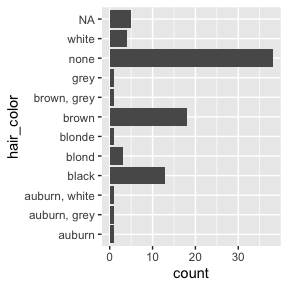

```r
ggplot(starwars, aes(y = hair_color)) +
  geom_bar()
```

That’s okay, but it would be more helpful the graph was ordered by count. This is a case of an **unordered** categorical variable where we want it ordered by its frequency. To do so, we can use the function `fct_infreq()`:

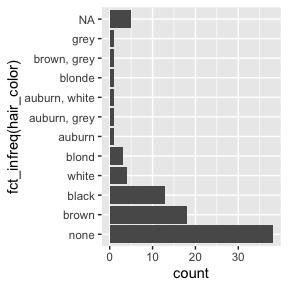

```r
ggplot(starwars, aes(y = fct_infreq(hair_color))) +
  geom_bar()
```

Note that `fct_infreq()` it automatically puts NA at the top, even though that doesn’t have the smallest number of entries.

It’s a little surprising that the `NA` bar isn’t ordered by frequency. To understand why we need to make a brief digression to discuss `NA`s in values vs. `NA`s in levels

## `NA`s in levels and values

There are two ways to represent a missing value in a factor:

- You can include it in the values of the factor; it does not appear in the levels and `is.na()` reports it as missing. This is how missing values are encoded in a factor by default:

  ```r
  f <- factor(c("x", "y", NA))
  levels(f)
  ```

  ```
  #> [1] "x" "y"
  ```

  ```r
  is.na(f)
  ```

  ```
  #> [1] FALSE FALSE  TRUE
  ```

- You can include it in the levels of the factor and `is.na()` does not report it as missing. This requires a little more work to create, because, by default, `factor()` uses `exclude = NA`, meaning that missing values are not included in the levels. You can force `NA` to be included by setting `exclude = NULL`:

  ```r
  f <- factor(c("x", "y", NA), exclude = NULL)
  levels(f)
  ```

  ```
  #> [1] "x" "y" NA
  ```

  ```r
  is.na(f)
  ```

  ```
  #> [1] FALSE FALSE FALSE
  ```

`NA`s in the values tend to be best for data analysis, since `is.na()` works as you’d expect. `NA`s in the levels can be useful for display if you need to control where they appear in a table or a plot.

To fix the issue above, we can use `fct_na_value_to_level()` to convert the `NA` in the value to an NA in the levels. Then they appear where you’d expect:

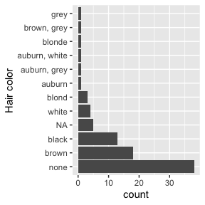

```r
ggplot(starwars, aes(y = fct_infreq(fct_na_value_to_level(hair_color)))) +
  geom_bar() +
  labs(y = "Hair color")
```

(If you need the opposite operation, you can use `fct_na_level_to_value()`.)

## Combining levels

Let’s take a look at skin color now:

```r
starwars |>
  count(skin_color, sort = TRUE)
```

```
#> # A tibble: 31 × 2
#>    skin_color     n
#>    <chr>      <int>
#>  1 fair          17
#>  2 light         11
#>  3 dark           6
#>  4 green          6
#>  5 grey           6
#>  6 pale           5
#>  7 brown          4
#>  8 blue           2
#>  9 blue, grey     2
#> 10 none           2
#> # ℹ 21 more rows
```

We see that there’s 31 different skin colors - if we want to make a plot this would be way too many to display! Let’s reduce it to only be the top 5. We can use `fct_lump()` to “lump” all the infrequent colors into one factor, “other.” The argument `n` is the number of levels we want to keep.

```r
starwars |>
  mutate(skin_color = fct_lump(skin_color, n = 5)) |>
  count(skin_color, sort = TRUE)
```

```
#> # A tibble: 6 × 2
#>   skin_color     n
#>   <fct>      <int>
#> 1 Other         41
#> 2 fair          17
#> 3 light         11
#> 4 dark           6
#> 5 green          6
#> 6 grey           6
```

We could also have used `prop` instead, which keeps all the levels that appear at least `prop` of the time. For example, let’s keep skin colors that at least 10% of the characters have:

```r
starwars |>
  mutate(skin_color = fct_lump(skin_color, prop = .1)) |>
  count(skin_color, sort = TRUE)
```

```
#> # A tibble: 3 × 2
#>   skin_color     n
#>   <fct>      <int>
#> 1 Other         59
#> 2 fair          17
#> 3 light         11
```

Only light and fair remain; everything else is other.

If you wanted to call it something than “other”, you can change it with the argument `other_level`:

```r
starwars |>
  mutate(skin_color = fct_lump(skin_color, prop = .1, other_level = "extra")) |>
  count(skin_color, sort = TRUE)
```

```
#> # A tibble: 3 × 2
#>   skin_color     n
#>   <fct>      <int>
#> 1 extra         59
#> 2 fair          17
#> 3 light         11
```

What if we wanted to see if the average mass differed by eye color? We’ll only look at the 6 most popular eye colors and remove `NA`s.

```r
avg_mass_eye_color <- starwars |>
  mutate(eye_color = fct_lump(eye_color, n = 6)) |>
  group_by(eye_color) |>
  summarise(mean_mass = mean(mass, na.rm = TRUE))

avg_mass_eye_color
```

```
#> # A tibble: 7 × 2
#>   eye_color mean_mass
#>   <fct>         <dbl>
#> 1 black          76.3
#> 2 blue           86.5
#> 3 brown          66.1
#> 4 orange        282.
#> 5 red            81.4
#> 6 yellow         81.1
#> 7 Other          68.4
```

## Ordering by another variable

It looks like people (or at least one person) with orange eyes are definitely heavier! If we wanted to make a graph, it would be nice if it was ordered by `mean_mass`. We can do this with `fct_reorder()`, which reorders one variable by another.

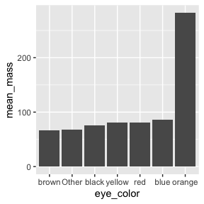

```r
avg_mass_eye_color |>
  mutate(eye_color = fct_reorder(eye_color, mean_mass)) |>
  ggplot(aes(x = eye_color, y = mean_mass)) +
  geom_col()
```

## Manually reordering

Let’s switch to using another dataset, `gss_cat`, the general social survey. What is the income distribution among the respondents?

```r
gss_cat |>
  count(rincome)
```

```
#> # A tibble: 16 × 2
#>    rincome            n
#>    <fct>          <int>
#>  1 No answer        183
#>  2 Don't know       267
#>  3 Refused          975
#>  4 $25000 or more  7363
#>  5 $20000 - 24999  1283
#>  6 $15000 - 19999  1048
#>  7 $10000 - 14999  1168
#>  8 $8000 to 9999    340
#>  9 $7000 to 7999    188
#> 10 $6000 to 6999    215
#> 11 $5000 to 5999    227
#> 12 $4000 to 4999    226
#> 13 $3000 to 3999    276
#> 14 $1000 to 2999    395
#> 15 Lt $1000         286
#> 16 Not applicable  7043
```

Notice that the income levels are in the correct order - they start with the non-answers and then go from highest to lowest. This is the same order you’d see if you plotted it as a bar chart. This is not a coincidence. When you’re working with ordinal data, where there is an order, you can have an ordered factor. You can examine them with the base function `levels()`, which prints them in order:

```r
levels(gss_cat$rincome)
```

```
#>  [1] "No answer"      "Don't know"     "Refused"        "$25000 or more"
#>  [5] "$20000 - 24999" "$15000 - 19999" "$10000 - 14999" "$8000 to 9999"
#>  [9] "$7000 to 7999"  "$6000 to 6999"  "$5000 to 5999"  "$4000 to 4999"
#> [13] "$3000 to 3999"  "$1000 to 2999"  "Lt $1000"       "Not applicable"
```

But what if your factor came in the wrong order? Let’s simulate that by reordering the levels of `rincome` randomly with `fct_shuffle()`:

```r
reshuffled_income <- gss_cat$rincome |>
  fct_shuffle()

levels(reshuffled_income)
```

```
#>  [1] "$25000 or more" "$5000 to 5999"  "$15000 - 19999" "Lt $1000"
#>  [5] "$8000 to 9999"  "$7000 to 7999"  "$10000 - 14999" "$6000 to 6999"
#>  [9] "$3000 to 3999"  "Refused"        "$1000 to 2999"  "No answer"
#> [13] "$4000 to 4999"  "Don't know"     "Not applicable" "$20000 - 24999"
```

Now if we plotted it, it would show in this order, which is all over the place! How can we fix this and put it in the right order?

We can use the function `fct_relevel()` when we need to manually reorder our factor levels. In addition to the factor, you give it a character vector of level names, and specify where you want to move them. It defaults to moving them to the front, but you can move them after another level with the argument `after`. If you want to move it to the end, you set `after` equal to `Inf`.

For example, let’s say we wanted to move `Lt $1000` and `$1000 to 2999` to the front. We would write:

```r
fct_relevel(reshuffled_income, c("Lt $1000", "$1000 to 2999")) |>
  levels()
```

```
#>  [1] "Lt $1000"       "$1000 to 2999"  "$25000 or more" "$5000 to 5999"
#>  [5] "$15000 - 19999" "$8000 to 9999"  "$7000 to 7999"  "$10000 - 14999"
#>  [9] "$6000 to 6999"  "$3000 to 3999"  "Refused"        "No answer"
#> [13] "$4000 to 4999"  "Don't know"     "Not applicable" "$20000 - 24999"
```

What if we want to move them to the second and third place?

```r
fct_relevel(reshuffled_income, c("Lt $1000", "$1000 to 2999"), after = 1) |>
  levels()
```

```
#>  [1] "$25000 or more" "Lt $1000"       "$1000 to 2999"  "$5000 to 5999"
#>  [5] "$15000 - 19999" "$8000 to 9999"  "$7000 to 7999"  "$10000 - 14999"
#>  [9] "$6000 to 6999"  "$3000 to 3999"  "Refused"        "No answer"
#> [13] "$4000 to 4999"  "Don't know"     "Not applicable" "$20000 - 24999"
```